# PENERAPAN LOGISTIC REGRESSION UNTUK DIAGNOSIS KANKER PARU-PARU

Kanker paru-paru adalah salah satu penyebab utama kematian akibat kanker di seluruh dunia. Salah satu alasan utamanya adalah deteksi yang terlambat, karena gejala kanker paru-paru sering kali tidak muncul hingga stadium lanjut. Deteksi dini sangat penting untuk meningkatkan peluang kesembuhan dan mengurangi tingkat kematian. Namun, metode deteksi tradisional seperti pencitraan medis (CT Scan) dan biopsi invasif cenderung mahal dan memakan waktu.

# PREPROCESSING DATA

## Mengumpulkan Data

Data yang akan digunakan adalah dataset yang didapat dari website Kaggle yaitu Lung Cancer atau Kanker Paru Paru ( https://www.kaggle.com/datasets/mysarahmadbhat/lung-cancer ). Dataset ini berisi data yang dikumpulkan dari website sistem prediksi kanker paru paru online, Dataset berisi 309 data dengan 270 penderita kanker paru paru dan 39 yang bukan penderita kanker paru paru, pada dataset ini tidak memiliki nilai missing atau missing value. Dataset ini memiliki 16 atribut dimana 15 atribut sedangkan 1 atribut class atau target.

|  | GENDER | AGE | SMOKING | YELLOW_FINGERS | ANXIETY | PEER_PRESSURE | CHRONIC DISEASE | FATIGUE | ALLERGY | WHEEZING | ALCOHOL CONSUMING | COUGHING | SHORTNESS OF BREATH | SWALLOWING DIFFICULTY | CHEST PAIN | LUNG_CANCER |
| --- | --- | --- | --- | --- | --- | --- | --- | --- | --- | --- | --- | --- | --- | --- | --- | --- |
| 0 | M | 69 | 1 | 2 | 2 | 1 | 1 | 2 | 1 | 2 | 2 | 2 | 2 | 2 | 2 | YES |
| 1 | M | 74 | 2 | 1 | 1 | 1 | 2 | 2 | 2 | 1 | 1 | 1 | 2 | 2 | 2 | YES |
| 2 | F | 59 | 1 | 1 | 1 | 2 | 1 | 2 | 1 | 2 | 1 | 2 | 2 | 1 | 2 | NO |
| 3 | M | 63 | 2 | 2 | 2 | 1 | 1 | 1 | 1 | 1 | 2 | 1 | 1 | 2 | 2 | NO |
| 4 | F | 63 | 1 | 2 | 1 | 1 | 1 | 1 | 1 | 2 | 1 | 2 | 2 | 1 | 1 | NO |
| ... | ... | ... | ... | ... | ... | ... | ... | ... | ... | ... | ... | ... | ... | ... | ... | ... |
| 304 | F | 56 | 1 | 1 | 1 | 2 | 2 | 2 | 1 | 1 | 2 | 2 | 2 | 2 | 1 | YES |
| 305 | M | 70 | 2 | 1 | 1 | 1 | 1 | 2 | 2 | 2 | 2 | 2 | 2 | 1 | 2 | YES |
| 306 | M | 58 | 2 | 1 | 1 | 1 | 1 | 1 | 2 | 2 | 2 | 2 | 1 | 1 | 2 | YES |
| 307 | M | 67 | 2 | 1 | 2 | 1 | 1 | 2 | 2 | 1 | 2 | 2 | 2 | 1 | 2 | YES |
| 308 | M | 62 | 1 | 1 | 1 | 2 | 1 | 2 | 2 | 2 | 2 | 1 | 1 | 2 | 1 | YES |

309 rows × 16 columns

Keterangan

- 1 = NO
- 2 = YES

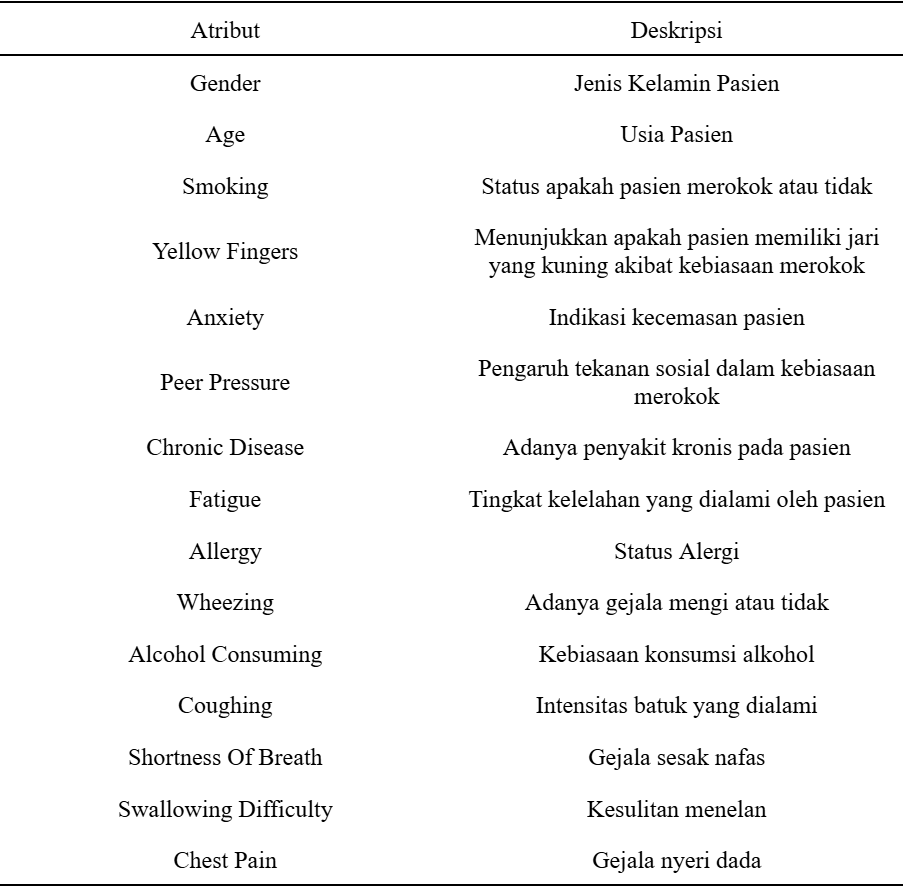

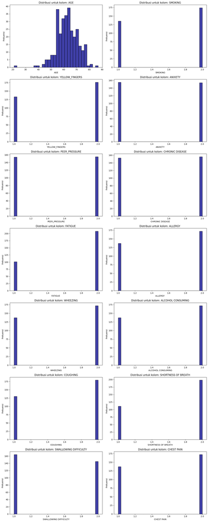

```
<class 'pandas.core.frame.DataFrame'>
RangeIndex: 309 entries, 0 to 308
Data columns (total 16 columns):
 #   Column                 Non-Null Count  Dtype
---  ------                 --------------  -----
 0   GENDER                 309 non-null    object
 1   AGE                    309 non-null    int64
 2   SMOKING                309 non-null    int64
 3   YELLOW_FINGERS         309 non-null    int64
 4   ANXIETY                309 non-null    int64
 5   PEER_PRESSURE          309 non-null    int64
 6   CHRONIC DISEASE        309 non-null    int64
 7   FATIGUE                309 non-null    int64
 8   ALLERGY                309 non-null    int64
 9   WHEEZING               309 non-null    int64
 10  ALCOHOL CONSUMING      309 non-null    int64
 11  COUGHING               309 non-null    int64
 12  SHORTNESS OF BREATH    309 non-null    int64
 13  SWALLOWING DIFFICULTY  309 non-null    int64
 14  CHEST PAIN             309 non-null    int64
 15  LUNG_CANCER            309 non-null    object
dtypes: int64(14), object(2)
memory usage: 38.8+ KB
```

|  | AGE | SMOKING | YELLOW_FINGERS | ANXIETY | PEER_PRESSURE | CHRONIC DISEASE | FATIGUE | ALLERGY | WHEEZING | ALCOHOL CONSUMING | COUGHING | SHORTNESS OF BREATH | SWALLOWING DIFFICULTY | CHEST PAIN |
| --- | --- | --- | --- | --- | --- | --- | --- | --- | --- | --- | --- | --- | --- | --- |
| count | 309.000000 | 309.000000 | 309.000000 | 309.000000 | 309.000000 | 309.000000 | 309.000000 | 309.000000 | 309.000000 | 309.000000 | 309.000000 | 309.000000 | 309.000000 | 309.000000 |
| mean | 62.673139 | 1.563107 | 1.569579 | 1.498382 | 1.501618 | 1.504854 | 1.673139 | 1.556634 | 1.556634 | 1.556634 | 1.579288 | 1.640777 | 1.469256 | 1.556634 |
| std | 8.210301 | 0.496806 | 0.495938 | 0.500808 | 0.500808 | 0.500787 | 0.469827 | 0.497588 | 0.497588 | 0.497588 | 0.494474 | 0.480551 | 0.499863 | 0.497588 |
| min | 21.000000 | 1.000000 | 1.000000 | 1.000000 | 1.000000 | 1.000000 | 1.000000 | 1.000000 | 1.000000 | 1.000000 | 1.000000 | 1.000000 | 1.000000 | 1.000000 |
| 25% | 57.000000 | 1.000000 | 1.000000 | 1.000000 | 1.000000 | 1.000000 | 1.000000 | 1.000000 | 1.000000 | 1.000000 | 1.000000 | 1.000000 | 1.000000 | 1.000000 |
| 50% | 62.000000 | 2.000000 | 2.000000 | 1.000000 | 2.000000 | 2.000000 | 2.000000 | 2.000000 | 2.000000 | 2.000000 | 2.000000 | 2.000000 | 1.000000 | 2.000000 |
| 75% | 69.000000 | 2.000000 | 2.000000 | 2.000000 | 2.000000 | 2.000000 | 2.000000 | 2.000000 | 2.000000 | 2.000000 | 2.000000 | 2.000000 | 2.000000 | 2.000000 |
| max | 87.000000 | 2.000000 | 2.000000 | 2.000000 | 2.000000 | 2.000000 | 2.000000 | 2.000000 | 2.000000 | 2.000000 | 2.000000 | 2.000000 | 2.000000 | 2.000000 |

## Missing Value

Pada langkah ini, akan dilakukan peninjauan dataset untuk memeriksa dan menangani data yang hilang (Missing Value), Untuk menangani missing value kami menggunakan nilai yang paling sering muncul (Mode / Modus).

|  | 0 |
| --- | --- |
| GENDER | 0 |
| AGE | 0 |
| SMOKING | 0 |
| YELLOW_FINGERS | 0 |
| ANXIETY | 0 |
| PEER_PRESSURE | 0 |
| CHRONIC DISEASE | 0 |
| FATIGUE | 0 |
| ALLERGY | 0 |
| WHEEZING | 0 |
| ALCOHOL CONSUMING | 0 |
| COUGHING | 0 |
| SHORTNESS OF BREATH | 0 |
| SWALLOWING DIFFICULTY | 0 |
| CHEST PAIN | 0 |
| LUNG_CANCER | 0 |

**dtype:** int64

## Outlier

```
OUTLIER
Outlier ditemukan pada baris => 69, kolom => AGE, nilai => 78
Outlier ditemukan pada baris => 83, kolom => AGE, nilai => 81
Outlier ditemukan pada baris => 101, kolom => AGE, nilai => 81
Outlier ditemukan pada baris => 204, kolom => AGE, nilai => 79
Outlier ditemukan pada baris => 230, kolom => AGE, nilai => 78
```

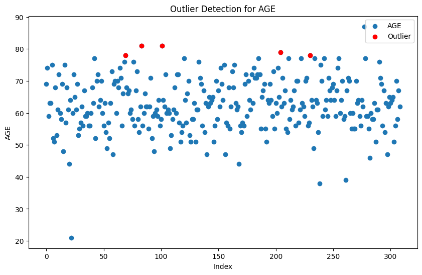

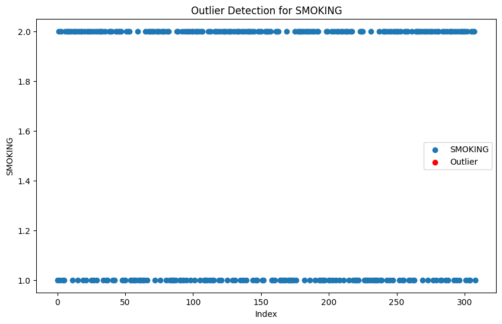

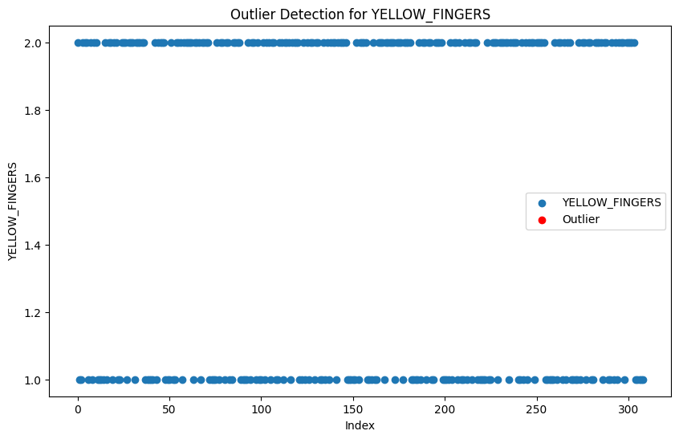

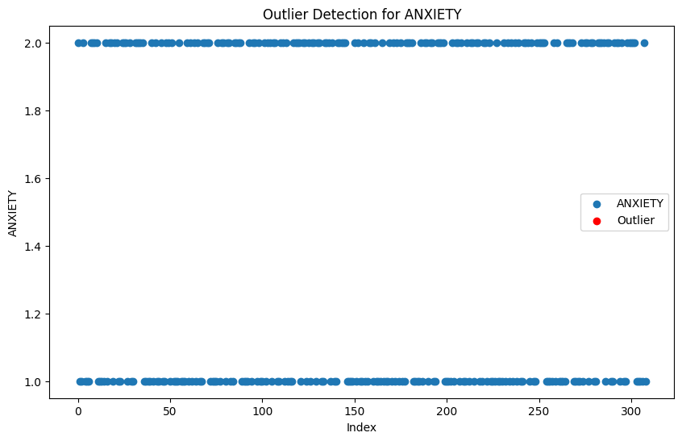

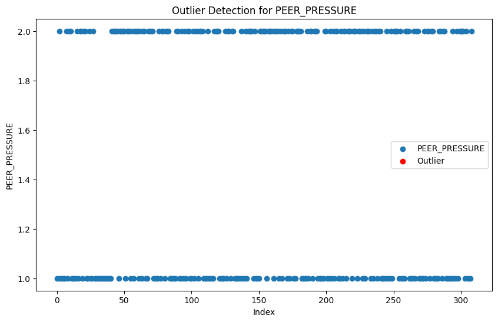

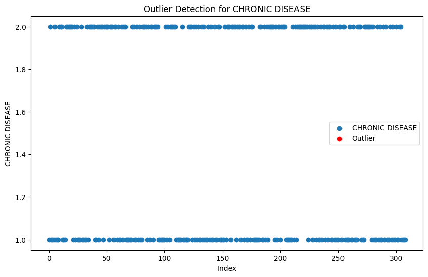

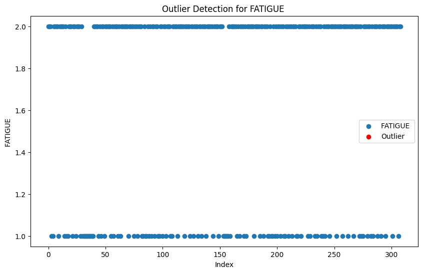

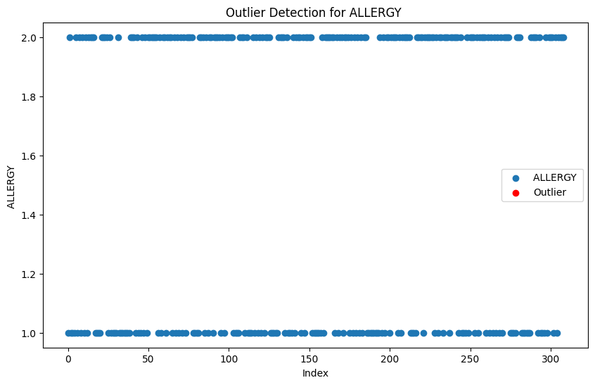

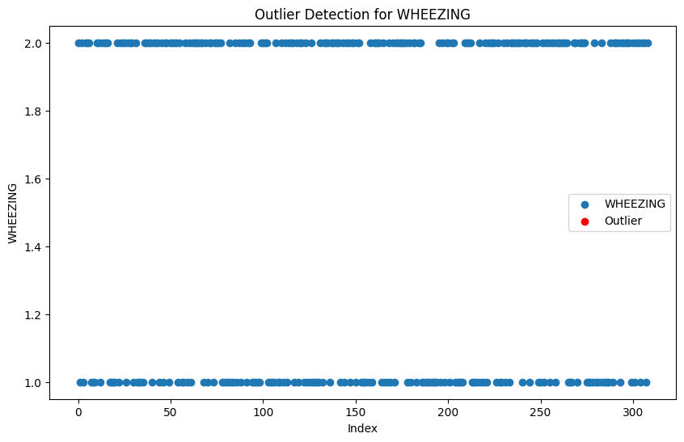

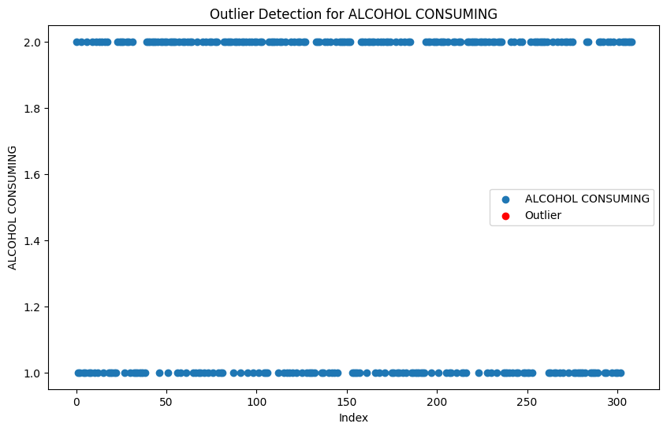

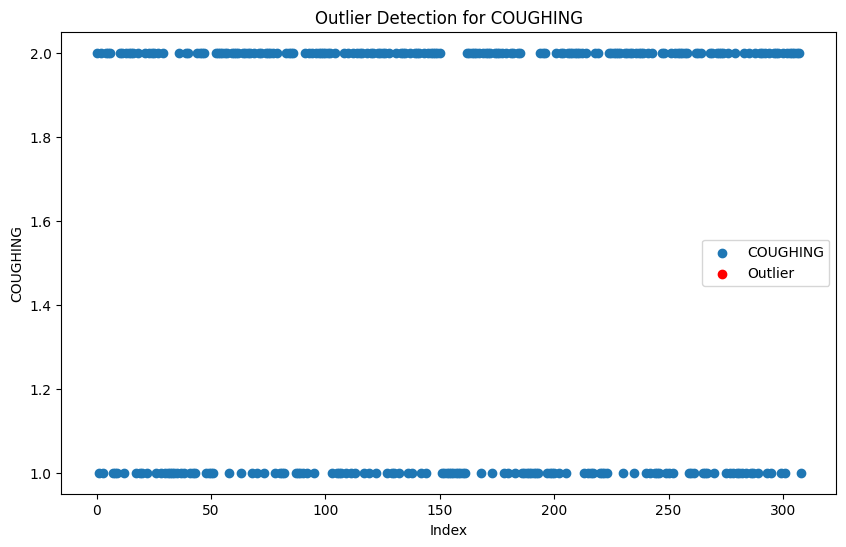

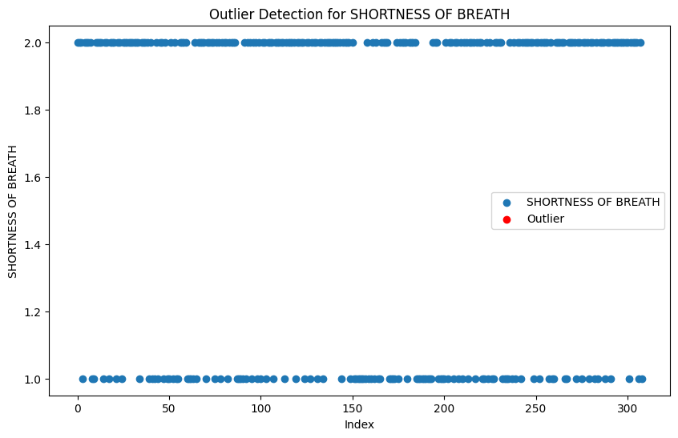

[2 more figures not shown]

## Normalisasi & Transformasi

### Encoding Kategorikal

- Kolom kategori seperti GENDER (dengan nilai "M" dan "F") diubah menjadi tipe numerik menggunakan label encoding.
- Label encoding mengonversi kategori menjadi angka, misalnya, "M" dan "F" dapat dikonversi menjadi 1 dan 2.

|  | GENDER | AGE | SMOKING | YELLOW_FINGERS | ANXIETY | PEER_PRESSURE | CHRONIC DISEASE | FATIGUE | ALLERGY | WHEEZING | ALCOHOL CONSUMING | COUGHING | SHORTNESS OF BREATH | SWALLOWING DIFFICULTY | CHEST PAIN | LUNG_CANCER |
| --- | --- | --- | --- | --- | --- | --- | --- | --- | --- | --- | --- | --- | --- | --- | --- | --- |
| 0 | 1 | 69 | 1 | 2 | 2 | 1 | 1 | 2 | 1 | 2 | 2 | 2 | 2 | 2 | 2 | 2 |
| 1 | 1 | 74 | 2 | 1 | 1 | 1 | 2 | 2 | 2 | 1 | 1 | 1 | 2 | 2 | 2 | 2 |
| 2 | 2 | 59 | 1 | 1 | 1 | 2 | 1 | 2 | 1 | 2 | 1 | 2 | 2 | 1 | 2 | 1 |
| 3 | 1 | 63 | 2 | 2 | 2 | 1 | 1 | 1 | 1 | 1 | 2 | 1 | 1 | 2 | 2 | 1 |
| 4 | 2 | 63 | 1 | 2 | 1 | 1 | 1 | 1 | 1 | 2 | 1 | 2 | 2 | 1 | 1 | 1 |
| ... | ... | ... | ... | ... | ... | ... | ... | ... | ... | ... | ... | ... | ... | ... | ... | ... |
| 304 | 2 | 56 | 1 | 1 | 1 | 2 | 2 | 2 | 1 | 1 | 2 | 2 | 2 | 2 | 1 | 2 |
| 305 | 1 | 70 | 2 | 1 | 1 | 1 | 1 | 2 | 2 | 2 | 2 | 2 | 2 | 1 | 2 | 2 |
| 306 | 1 | 58 | 2 | 1 | 1 | 1 | 1 | 1 | 2 | 2 | 2 | 2 | 1 | 1 | 2 | 2 |
| 307 | 1 | 67 | 2 | 1 | 2 | 1 | 1 | 2 | 2 | 1 | 2 | 2 | 2 | 1 | 2 | 2 |
| 308 | 1 | 62 | 1 | 1 | 1 | 2 | 1 | 2 | 2 | 2 | 2 | 1 | 1 | 2 | 1 | 2 |

309 rows × 16 columns

### Normalisasi

|  | GENDER | AGE | SMOKING | YELLOW_FINGERS | ANXIETY | PEER_PRESSURE | CHRONIC DISEASE | FATIGUE | ALLERGY | WHEEZING | ALCOHOL CONSUMING | COUGHING | SHORTNESS OF BREATH | SWALLOWING DIFFICULTY | CHEST PAIN | LUNG_CANCER |
| --- | --- | --- | --- | --- | --- | --- | --- | --- | --- | --- | --- | --- | --- | --- | --- | --- |
| 0 | 1 | 1.727273 | 1 | 2 | 2 | 1 | 1 | 2 | 1 | 2 | 2 | 2 | 2 | 2 | 2 | 2 |
| 1 | 1 | 1.803030 | 2 | 1 | 1 | 1 | 2 | 2 | 2 | 1 | 1 | 1 | 2 | 2 | 2 | 2 |
| 2 | 2 | 1.575758 | 1 | 1 | 1 | 2 | 1 | 2 | 1 | 2 | 1 | 2 | 2 | 1 | 2 | 1 |
| 3 | 1 | 1.636364 | 2 | 2 | 2 | 1 | 1 | 1 | 1 | 1 | 2 | 1 | 1 | 2 | 2 | 1 |
| 4 | 2 | 1.636364 | 1 | 2 | 1 | 1 | 1 | 1 | 1 | 2 | 1 | 2 | 2 | 1 | 1 | 1 |
| ... | ... | ... | ... | ... | ... | ... | ... | ... | ... | ... | ... | ... | ... | ... | ... | ... |
| 304 | 2 | 1.530303 | 1 | 1 | 1 | 2 | 2 | 2 | 1 | 1 | 2 | 2 | 2 | 2 | 1 | 2 |
| 305 | 1 | 1.742424 | 2 | 1 | 1 | 1 | 1 | 2 | 2 | 2 | 2 | 2 | 2 | 1 | 2 | 2 |
| 306 | 1 | 1.560606 | 2 | 1 | 1 | 1 | 1 | 1 | 2 | 2 | 2 | 2 | 1 | 1 | 2 | 2 |
| 307 | 1 | 1.696970 | 2 | 1 | 2 | 1 | 1 | 2 | 2 | 1 | 2 | 2 | 2 | 1 | 2 | 2 |
| 308 | 1 | 1.621212 | 1 | 1 | 1 | 2 | 1 | 2 | 2 | 2 | 2 | 1 | 1 | 2 | 1 | 2 |

309 rows × 16 columns

# MODELLING

## Model Building menggunakan Regresi Logistik

### Memisahkan Fitur Target

memisahkan fitur-fitur yang akan digunakan dalam prediksi kanker paru-paru dari kolom target (LUNG_CANCER).

```
Fitur yang digunakan(x) :
* GENDER
* AGE
* SMOKING
* YELLOW_FINGERS
* ANXIETY
* PEER_PRESSURE
* CHRONIC DISEASE
* FATIGUE
* ALLERGY
* WHEEZING
* ALCOHOL CONSUMING
* COUGHING
* SHORTNESS OF BREATH
* SWALLOWING DIFFICULTY
* CHEST PAIN

Fitur Target (y):
*  LUNG_CANCER
```

### Membagi Data Menjadi Data Latih Dan Data Uji

Setelah memilih fitur, kita membagi dataset menjadi data latih (training) dan data uji (testing) untuk mengevaluasi performa model. Disini, kita akan menggunakan 80% data untuk pelatihan dan 20% untuk pengujian.

```
Ukuran data latih: 247 baris
Ukuran data uji: 62 baris
```

### Membangun Model Klasifikasi

```
Akurasi Model: 96.77%
Classification Report:
               precision    recall  f1-score   support

           1       0.50      0.50      0.50         2
           2       0.98      0.98      0.98        60

    accuracy                           0.97        62
   macro avg       0.74      0.74      0.74        62
weighted avg       0.97      0.97      0.97        62
```

## Model Building menggunakan Gaussian Naive Bayes

### Memisahkan Fitur Target

memisahkan fitur-fitur yang akan digunakan dalam prediksi kanker paru-paru dari kolom target (LUNG_CANCER).

```
Fitur yang digunakan(x) :
* GENDER
* AGE
* SMOKING
* YELLOW_FINGERS
* ANXIETY
* PEER_PRESSURE
* CHRONIC DISEASE
* FATIGUE
* ALLERGY
* WHEEZING
* ALCOHOL CONSUMING
* COUGHING
* SHORTNESS OF BREATH
* SWALLOWING DIFFICULTY
* CHEST PAIN

Fitur Target (y):
*  LUNG_CANCER
```

### Membagi Data Menjadi Data Latih Dan Data Uji

Setelah memilih fitur, kita membagi dataset menjadi data latih (training) dan data uji (testing) untuk mengevaluasi performa model. Disini, kita akan menggunakan 80% data untuk pelatihan dan 20% untuk pengujian.

```
Ukuran data latih: 247 baris
Ukuran data uji: 62 baris
```

### Membangun Model Klasifikasi

```
Akurasi Model: 95.16%
Classification Report:
               precision    recall  f1-score   support

           1       0.33      0.50      0.40         2
           2       0.98      0.97      0.97        60

    accuracy                           0.95        62
   macro avg       0.66      0.73      0.69        62
weighted avg       0.96      0.95      0.96        62
```

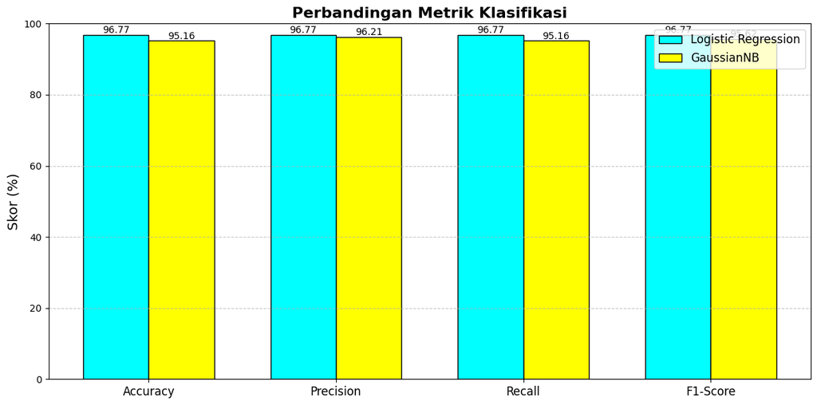

Dari beberapa tahapan pengerjaan yang telah kita lalui, kami mendapatkan kesimpulan bahwa hasil yang terbaik untuk di bawa ke tahapan selanjutnya adalah dengan menggunakan model dari regresi logistik.

Dapat dilihat kembali hasil akurasi dengan Regresi Logistik lebih tinggi dibandingkan akurasi dengan Gaussian Naive Bayes, dimana akurasi Regresi Logistik adalah 96.77% sedangakan akurasi Gaussian Naive Bayes adalah 95.16%

# EKSPLORASI UNTUK MENCARI AKURASI TERTINGGI

## Eksplorasi Akurasi Dengan Smote

SMOTE (Synthetic Minority Oversampling Technique) adalah teknik yang digunakan untuk mengatasi masalah ketidakseimbangan data dalam dataset klasifikasi. Ketidakseimbangan data terjadi ketika jumlah sampel dalam satu kelas (kelas mayoritas) jauh lebih banyak dibandingkan dengan kelas lain (kelas minoritas).

### Regresi Logistik

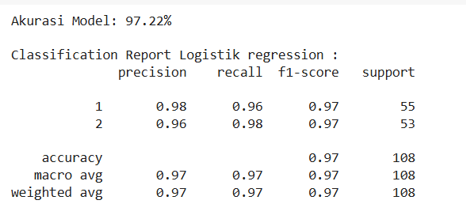

### Gaussian Naive Bayes

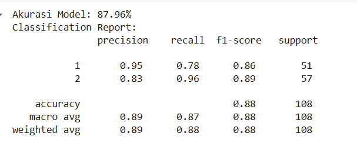

## Eksplorasi Parameter Model

### Regresi logistik

##### 1. Mengganti Solver Logistic Regression di scikit-learn memiliki beberapa pilihan solver, seperti: 'lbfgs': Solver yang efisien untuk banyak masalah, digunakan digunakan untuk dataset dengan banyak fitur (kolom).. 'liblinear': Cocok untuk dataset yang lebih kecil atau ketika menggunakan regulasi L1. 'saga': Digunakan untuk dataset besar atau ketika regulasi L1 atau L2 digunakan.

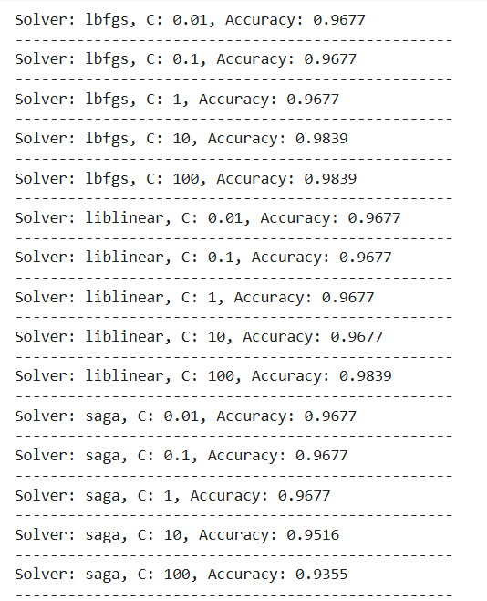

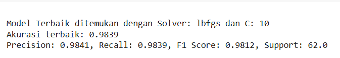

### Gaussian Naive Bayes

Mengubah Bobot pada gaussian naive bayes, didapatkan akurasi sebesar :

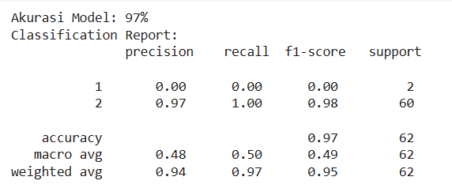

# KESIMPULAN

Dari beberapa tahapan pengerjaan yang telah kita lalui, kami mendapatkan kesimpulan bahwa hasil yang terbaik untuk di bawa ke tahapan selanjutnya adalah dengan menggunakan model dari regresi logistik dengan mengubah solver dan C(penalty parameter).

Dapat dilihat kembali hasil akurasi regresi logistik lebih tinggi daripada akurasi model yang lain, akurasinya mencapai 0.9839